[figure not shown]

# TP3: Quelques méthodes supervisées

# Table of contents

1. K plus proches voisins : Test et validation de modeles Illustrez la méthode
2. SVM
3. Arbre de decision
4. Forêt aléatoire

## Exercice 1: K plus proches voisins : Test et validation de modeles Illustrez la méthode

### 1. Tester et interpreter le segment de code qui suit.

```python
import numpy as np
import matplotlib.pyplot as plt
from sklearn.datasets import load_iris
from sklearn.linear_model import LinearRegression
# lecture des données
iris = load_iris ()
X = iris.data
y = iris.target
```

Dans cette exemple la classification qui va se faire en se basant sur 4 paramètres à la fois: sepal length, sepal width, petal length, petal width pour déterminer les espèces

### 2. Créer le classifieur à l’aide du module KNeighborsClassifier.

```python
from sklearn . neighbors import KNeighborsClassifier
model = KNeighborsClassifier(n_neighbors =1)
```

### 3. Entraîner le modèle et en déduire le nombre de points correctement étiqueté.

```python
# entraînement du modèle
model.fit(X, y)
y_model = model.predict (X)
# nombre de points correctement étiquetés
from sklearn.metrics import accuracy_score
accuracy_score(y, y_model)
```

```
1.0
```

Nous voyons un score de précision de 1.0, ce qui indique que 100% des points ont été correctement étiquetés par notre modèle!  
Cependant cette approche comporte un défaut fondamental: elle forme et évalue le modèle sur les mêmes données. De plus, le modèle du voisin le plus proche est un estimateur basé sur une instance qui stocke simplement les données d'apprentissage et prédit les étiquettes en comparant les nouvelles données à ces points stockés: sauf dans les cas artificiels, il obtiendra une précision de 100% à chaque fois!

### 4. Valider le modèle à l’aide des données test et interpréter les résultats obtenus.

```python
from sklearn.model_selection import train_test_split
# subdiviser les données en deux parties
X1, X2, y1, y2 = train_test_split (X, y, random_state =0, train_size =0.5)

# utiliser une partie des données pour
# entraîner le modèle
model.fit (X1 , y1)
# évaluer le modèle sur la seconde partie des données
y2_model = model.predict (X2)
# taux d’exactitude
accuracy_score(y2, y2_model)
```

```
0.9066666666666666
```

Nous voyons ici un résultat plus raisonnable: le classificateur du plus proche voisin est précis à plus de 90% sur cet ensemble de retenue. Le jeu d'exclusion est similaire aux données inconnues, car le modèle ne l'a pas «vu» auparavant.

### 5. Valider le modèle à l’aide de la validation croisée.

```python
### deux patchs
y2_model = model.fit (X1 , y1 ).predict (X2)
y1_model = model.fit (X2 , y2 ).predict (X1)
accuracy_score(y1, y1_model), accuracy_score(y2, y2_model)
## patchs avec le module cross_val_score
from sklearn.model_selection import cross_val_score
cross_val_score (model , X, y, cv =5)
## avec la methode LeaveOneOut
from sklearn.model_selection import LeaveOneOut
scores = cross_val_score(model , X, y, cv= LeaveOneOut())
scores
```

```
array([1., 1., 1., 1., 1., 1., 1., 1., 1., 1., 1., 1., 1., 1., 1., 1., 1.,
       1., 1., 1., 1., 1., 1., 1., 1., 1., 1., 1., 1., 1., 1., 1., 1., 1.,
       1., 1., 1., 1., 1., 1., 1., 1., 1., 1., 1., 1., 1., 1., 1., 1., 1.,
       1., 1., 1., 1., 1., 1., 1., 1., 1., 1., 1., 1., 1., 1., 1., 1., 1.,
       1., 1., 0., 1., 0., 1., 1., 1., 1., 1., 1., 1., 1., 1., 1., 0., 1.,
       1., 1., 1., 1., 1., 1., 1., 1., 1., 1., 1., 1., 1., 1., 1., 1., 1.,
       1., 1., 1., 1., 0., 1., 1., 1., 1., 1., 1., 1., 1., 1., 1., 1., 1.,
       0., 1., 1., 1., 1., 1., 1., 1., 1., 1., 1., 1., 1., 1., 0., 1., 1.,
       1., 1., 1., 1., 1., 1., 1., 1., 1., 1., 1., 1., 1., 1.])
```

```python
scores.mean()
```

```
0.96
```

### 6. GridSearch

#### a. Decrivez la méthode et comparez le aux méthodes précédentes.

GridSearch est le processus qui consiste à effectuer un réglage d'hyper paramètre afin de déterminer les valeurs optimales pour un modèle donné.

**Avantages:** Recherche exhaustive, trouvera le meilleur moyen de régler les hyperparamètres en fonction de l'ensemble d'entraînement.

**Inconvénients:** Long, risque de sur-ajustement

L'approche GridSearch convient lorsque nous explorons relativement peu de combinaisons, mais lorsque l'espace de recherche des hyperparamètres est grand, il est souvent préférable d'utiliser RandomizedSearch à la place. Cette classe peut être utilisée de la même manière que la classe GridSearch, mais au lieu d'essayer toutes les combinaisons possibles, il évalue un nombre donné de combinaisons aléatoires en sélectionnant une valeur aléatoire pour chaque hyperparamètre à chaque itération.

**Avantages:** Risque réduit de surajustement, beaucoup plus rapide que la recherche de grille.

**Inconvénients:** Beaucoup de potentiel variance vu que c'est aléatoire

#### b. Importer les modules et fixer les paramètres.

```python
import numpy as np

def make_data(N, err=1.0, rseed=1):
    # randomly sample the data
    rng = np.random.RandomState(rseed)
    X = rng.rand(N, 1) ** 2
    y = 10 - 1. / (X.ravel() + 0.1)
    if err > 0:
        y += err * rng.randn(N)
    return X, y

X, y = make_data(40)
```

```python
from sklearn.preprocessing import PolynomialFeatures
from sklearn.linear_model import LinearRegression
from sklearn.pipeline import make_pipeline

def PolynomialRegression():
    return make_pipeline(PolynomialFeatures(), LinearRegression())

X_test = np.linspace(-0.1, 1.1, 500)[:, None]
y_test = PolynomialRegression().fit(X, y).predict(X_test)
```

```python
from sklearn.model_selection import GridSearchCV
param_grid = {'polynomialfeatures__degree': np.arange(21),
              'linearregression__fit_intercept': [True , False],
              'linearregression__normalize': [True, False]}

grid = GridSearchCV(PolynomialRegression(), param_grid, cv =7)
# entraînement
grid.fit(X, y);
```

#### c. En vous inspirant du script qui suit chercher le meilleur paramètre.

```
(-0.05673314103942452,
 0.994263633135634,
 -0.7459943120970807,
 10.918045992764213)
```

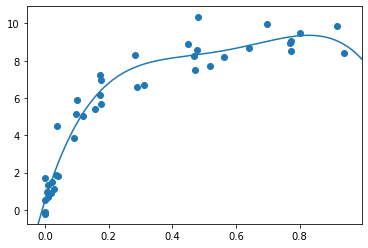

```python
model = grid.best_estimator_
plt.scatter(X.ravel(), y)
lim = plt.axis()
y_test = model.fit(X, y).predict(X_test)
plt.plot(X_test.ravel(), y_test);
plt.axis(lim)
```

#### d. Interpréter les résultats obtenus.

```python
# Les meilleurs parametres pour notre modele sont finalement
grid.best_params_
```

```
{'linearregression__fit_intercept': False,
 'linearregression__normalize': True,
 'polynomialfeatures__degree': 4}
```

## Exercice 2: SVM

**Illustrez la méthode SVM sur un problème et sur des données de votre choix. Ensuite discuter sur les choix des paramètres et de la performance.**

Chargons l'ensemble de données à l'aide de la fonction fetch_california_housing () disponible sur Scikit-Learn:

```python
from sklearn.datasets import fetch_california_housing
housing = fetch_california_housing()
X = housing["data"]
y = housing["target"]
```

Divisons-le en un ensemble d'entraînement et un ensemble de test:

```python
from sklearn.model_selection import train_test_split

X_train, X_test, y_train, y_test = train_test_split(X, y, test_size=0.2, random_state=42)
```

Mettons à l'échelle les données (normalisation):

```python
from sklearn.preprocessing import StandardScaler

scaler = StandardScaler()
X_train_scaled = scaler.fit_transform(X_train)
X_test_scaled = scaler.transform(X_test)
```

Entraînons d'abord un simple LinearSVR:

```python
from sklearn.svm import LinearSVR

lin_svr = LinearSVR(random_state=42)
lin_svr.fit(X_train_scaled, y_train)
```

```
LinearSVR(C=1.0, dual=True, epsilon=0.0, fit_intercept=True,
          intercept_scaling=1.0, loss='epsilon_insensitive', max_iter=1000,
          random_state=42, tol=0.0001, verbose=0)
```

Voyons comment cela fonctionne sur l'ensemble d'entraînement:

```python
from sklearn.metrics import mean_squared_error

y_pred = lin_svr.predict(X_train_scaled)
mse = mean_squared_error(y_train, y_pred)
mse
```

```
0.9612806653297273
```

Regardons le RMSE:

```python
np.sqrt(mse)
```

```
0.9804492160890983
```

Dans cet ensemble de formation, les objectifs sont de dizaines de milliers de dollars. Le RMSE donne une idée approximative du type d'erreur auquel nous devrons nous attendre (avec un poids plus élevé pour les grosses erreurs): donc avec ce modèle, nous pouvons nous attendre à des erreurs d'environ 10000$. Pas génial. Voyons si nous pouvons faire mieux avec un noyau RBF. Nous utiliserons la recherche aléatoire avec validation croisée pour trouver les valeurs d'hyperparamètres appropriées pour C et gamma:

```python
from sklearn.svm import SVR
from sklearn.model_selection import RandomizedSearchCV
from scipy.stats import reciprocal, uniform

param_distributions = {"gamma": reciprocal(0.001, 0.1), "C": uniform(1, 10)}
rnd_search_cv = RandomizedSearchCV(SVR(), param_distributions, n_iter=10, verbose=2, cv=3, random_state=42)
rnd_search_cv.fit(X_train_scaled, y_train)
```

```
[Parallel(n_jobs=1)]: Using backend SequentialBackend with 1 concurrent workers.
```

```
Fitting 3 folds for each of 10 candidates, totalling 30 fits
[CV] C=4.745401188473625, gamma=0.07969454818643928 ..................
[CV] ... C=4.745401188473625, gamma=0.07969454818643928, total=   9.8s
[CV] C=4.745401188473625, gamma=0.07969454818643928 ..................
```

```
[Parallel(n_jobs=1)]: Done   1 out of   1 | elapsed:    9.7s remaining:    0.0s
```

[output not shown]

```
[Parallel(n_jobs=1)]: Done  30 out of  30 | elapsed:  4.8min finished
```

```
RandomizedSearchCV(cv=3, error_score=nan,
                   estimator=SVR(C=1.0, cache_size=200, coef0=0.0, degree=3,
                                 epsilon=0.1, gamma='scale', kernel='rbf',
                                 max_iter=-1, shrinking=True, tol=0.001,
                                 verbose=False),
                   iid='deprecated', n_iter=10, n_jobs=None,
                   param_distributions={'C': <scipy.stats._distn_infrastructure.rv_frozen object at 0x000001CC5F6B1208>,
                                        'gamma': <scipy.stats._distn_infrastructure.rv_frozen object at 0x000001CC5F434248>},
                   pre_dispatch='2*n_jobs', random_state=42, refit=True,
                   return_train_score=False, scoring=None, verbose=2)
```

```python
rnd_search_cv.best_estimator_
```

```
SVR(C=4.745401188473625, cache_size=200, coef0=0.0, degree=3, epsilon=0.1,
    gamma=0.07969454818643928, kernel='rbf', max_iter=-1, shrinking=True,
    tol=0.001, verbose=False)
```

Maintenant, mesurons le RMSE sur l'ensemble d'entraînement:

```python
y_pred = rnd_search_cv.best_estimator_.predict(X_train_scaled)
mse = mean_squared_error(y_train, y_pred)
np.sqrt(mse)
```

```
0.5727524770785357
```

Ressemble beaucoup mieux que le modèle linéaire. Sélectionnons ce modèle et évaluons-le sur l'ensemble de test:

```python
y_pred = rnd_search_cv.best_estimator_.predict(X_test_scaled)
mse = mean_squared_error(y_test, y_pred)
np.sqrt(mse)
```

```
0.5929168385528746
```

## Exercice 3: Arbre de decision

Entraînez et réglez précisément un arbre de décision pour le jeu de données moons.

### 1. Avec make_moons(n_samples = 10000, noise = 0.4)

#### a. générez un jeu de données moons.

```python
from sklearn.datasets import make_moons
X, y = make_moons(n_samples=10000, noise=0.4, random_state=42)
```

#### b. Décrire et interprétez les données.

Cette fonction est utilisée pour les problèmes de classification binaire avec deux classes et génère des motifs en forme de lune. Elle nous permet de spécifier le niveau de bruit dans les données. Cela nous aide à rendre l'ensemble de données plus complexe si nécessaire pour tester la robustesse d'un algorithme.

**Maintenant, nous pouvons simplement utiliser le code du dernier exemple pour visualiser les données:**

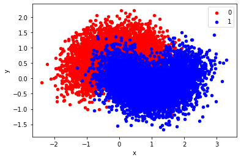

```python
# Plot a scatter plot, color
import pandas as pd
df = pd.DataFrame(dict(x=X[:,0], y=X[:,1], label=y))
colors = {0:'red', 1:'blue', 2:'green'}
fig, ax = plt.subplots()
grouped = df.groupby('label')
for key, group in grouped:
    group.plot(ax=ax, kind='scatter', x='x', y='y', label=key, color=colors[key])
plt.show()
```

Nous pouvons également voir que ce modèle n'est pas linéairement séparable, c'est-à-dire que nous ne pouvons pas tracer une ligne droite pour séparer les classes, cela nous aide à essayer nos fonctions de classification non linéaires (ici le DecisionTree.)

### 2. Partagez-le entre un jeu d’entraînement et un jeu de test à l’aide de train_test_split()

```python
from sklearn.model_selection import train_test_split
X_train, X_test, y_train, y_test = train_test_split(X, y, test_size=0.2, random_state=42)
```

### 3. Utilisez une recherche par quadrillage avec validation croisée (à l’aide de la classe GridSearchCV)

```python
from sklearn.model_selection import GridSearchCV
from sklearn.tree import DecisionTreeClassifier
params = {'max_leaf_nodes': list(range(2, 100)), 'min_samples_split': [2, 3, 4]}
grid_search_cv = GridSearchCV(DecisionTreeClassifier(random_state=42), params, verbose=1, cv=3)
#entrainement
grid_search_cv.fit(X_train, y_train)
```

```
Fitting 3 folds for each of 294 candidates, totalling 882 fits
```

```
[Parallel(n_jobs=1)]: Using backend SequentialBackend with 1 concurrent workers.
[Parallel(n_jobs=1)]: Done 882 out of 882 | elapsed:   15.9s finished
```

```
GridSearchCV(cv=3, error_score=nan,
             estimator=DecisionTreeClassifier(ccp_alpha=0.0, class_weight=None,
                                              criterion='gini', max_depth=None,
                                              max_features=None,
                                              max_leaf_nodes=None,
                                              min_impurity_decrease=0.0,
                                              min_impurity_split=None,
                                              min_samples_leaf=1,
                                              min_samples_split=2,
                                              min_weight_fraction_leaf=0.0,
                                              presort='deprecated',
                                              random_state=42,
                                              splitter='best'),
             iid='deprecated', n_jobs=None,
             param_grid={'max_leaf_nodes': [2, 3, 4, 5, 6, 7, 8, 9, 10, 11, 12,
                                            13, 14, 15, 16, 17, 18, 19, 20, 21,
                                            22, 23, 24, 25, 26, 27, 28, 29, 30,
                                            31, ...],
                         'min_samples_split': [2, 3, 4]},
             pre_dispatch='2*n_jobs', refit=True, return_train_score=False,
             scoring=None, verbose=1)
```

```python
grid_search_cv.best_estimator_
```

```
DecisionTreeClassifier(ccp_alpha=0.0, class_weight=None, criterion='gini',
                       max_depth=None, max_features=None, max_leaf_nodes=17,
                       min_impurity_decrease=0.0, min_impurity_split=None,
                       min_samples_leaf=1, min_samples_split=2,
                       min_weight_fraction_leaf=0.0, presort='deprecated',
                       random_state=42, splitter='best')
```

On peut voir ci dessous les meilleurs paramètres pour construire notre modèle avec best_estimator_

### 4. Ensuite

#### a. Entraînez l’arbre de décision sur l’ensemble du jeu d’entraînement en utilisant ces hyperparamètres,.

Par défaut, GridSearchCV entraîne le meilleur modèle trouvé sur l'ensemble de l'entraînement (il est possible de changer cela en définissant refit = False), nous n'avons donc pas besoin de le refaire. Nous pouvons simplement évaluer la précision du modèle.

#### b. mesurez les performances de votre modèle sur le jeu de test.

```python
from sklearn.metrics import accuracy_score
y_pred = grid_search_cv.predict(X_test)
accuracy_score(y_test, y_pred)
```

```
0.8695
```

#### c. Interprétez les résultats obtenus..

Notre modèle fournit un assez bon accuracy avec une valeur de 0.8695

## Exercice 4: Forêt aléatoire

Chargez le jeu de données MNIST

```python
%%time
from sklearn.datasets import fetch_openml
mnist = fetch_openml(data_id=554) # https://www.openml.org/d/554
```

```
Wall time: 54.2 s
```

```python
X, y = mnist["data"], mnist["target"]
```

### 1. Reduction de dimension

#### a. Partagez le jeu de données MNIST entre un jeu d’entraînement et un jeu de test.

```python
X_train = mnist['data'][:60000]
y_train = mnist['target'][:60000]

X_test = mnist['data'][60000:]
y_test = mnist['target'][60000:]
```

#### b. Entraînez un classificateur de type forêt aléatoire sur le premier jeu et mesurez le temps de calcul, puis évaluez le modèle obtenu.

```python
from sklearn.ensemble import RandomForestClassifier
rnd_clf = RandomForestClassifier(n_estimators=10, random_state=42)
```

```python
import time
t0 = time.time()
rnd_clf.fit(X_train, y_train)
t1 = time.time()
```

```python
print("Training took {:.2f}s".format(t1 - t0))
```

```
Training took 7.85s
```

```python
from sklearn.metrics import accuracy_score
y_pred = rnd_clf.predict(X_test)
accuracy_score(y_test, y_pred)
```

```
0.9492
```

#### c. Entraînez un nouveau classificateur de type forêt aléatoire sur le jeu de donnée réduit et mesurez le temps de calcul.

```python
from sklearn.decomposition import PCA
pca = PCA(n_components=0.95)
X_train_reduced = pca.fit_transform(X_train)
```

```python
rnd_clf2 = RandomForestClassifier(n_estimators=10, random_state=42)
t0 = time.time()
rnd_clf2.fit(X_train_reduced, y_train)
t1 = time.time()
```

```python
print("Training took {:.2f}s".format(t1 - t0))
```

```
Training took 20.67s
```

L'entraînement est en fait plus de deux fois plus lent maintenant! Nous pouvons en déduire que la réduction de la dimension ne conduit pas toujours à un temps d'apprentissage plus rapide: cela dépend du jeu de données, du modèle et de l'algorithme d'apprentissage.

#### d. Evaluez ensuite le classificateur sur le jeu de test : est-il meilleur ou moins bon que le précédent ?

```python
X_test_reduced = pca.transform(X_test)
y_pred = rnd_clf2.predict(X_test_reduced)
accuracy_score(y_test, y_pred)
```

```
0.9009
```

Il est courant que les performances diminuent légèrement lors de la réduction de la dimension vu que nous perdons un signal utile dans le processus. Cependant, la baisse des performances est assez sévère dans ce cas. Le PCA n'a donc pas vraiment aidé: il a ralenti l'entraînement et réduit les performances.

#### e. Ensuite réduire le jeu de données MNIST à deux dimensions puis représentez graphiquement le résultat en utilisant MatplotLib.

```python
np.random.seed(42)
m = 10000
idx = np.random.permutation(60000)[:m]
X = mnist['data'][idx]
y = mnist['target'][idx]
```

```
PCA took 0.8s.
```

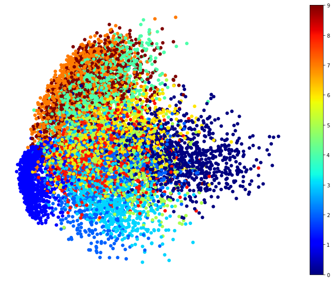

```python
from sklearn.decomposition import PCA
import time
t0 = time.time()
X_pca_reduced = PCA(n_components=2, random_state=42).fit_transform(X)
t1 = time.time()
print("PCA took {:.1f}s.".format(t1 - t0))

#Affichage
plt.figure(figsize=(13,10))
plt.scatter(X_pca_reduced[:, 0].astype(int), X_pca_reduced[:, 1].astype(int), c=y.astype(int), cmap="jet")
plt.axis('off')
plt.colorbar()
plt.show()
```

### 2. Classification

#### a. Chargez les données MNIST et partagez-les entre un jeu d’entraînement, un jeu de validation et un jeu de test.

```python
from sklearn.model_selection import train_test_split
```

```python
X_train_val, X_test, y_train_val, y_test = train_test_split(
    mnist.data, mnist.target, test_size=10000, random_state=42)
X_train, X_val, y_train, y_val = train_test_split(
    X_train_val, y_train_val, test_size=10000, random_state=42)
```

#### b. Ensuite

**i. Entraînez différentes classificateurs, de type forêt aléatoire, extra-arbres et SVM**

```python
from sklearn.ensemble import RandomForestClassifier, ExtraTreesClassifier
from sklearn.svm import LinearSVC
```

```python
random_forest_clf = RandomForestClassifier(n_estimators=100, random_state=42)
extra_trees_clf = ExtraTreesClassifier(n_estimators=100, random_state=42)
svm_clf = LinearSVC(random_state=42)
```

```python
estimators = [random_forest_clf, extra_trees_clf, svm_clf]
for estimator in estimators:
    print("Training the", estimator)
    estimator.fit(X_train, y_train)
```

```
Training the RandomForestClassifier(bootstrap=True, ccp_alpha=0.0, class_weight=None,
                       criterion='gini', max_depth=None, max_features='auto',
                       max_leaf_nodes=None, max_samples=None,
                       min_impurity_decrease=0.0, min_impurity_split=None,
                       min_samples_leaf=1, min_samples_split=2,
                       min_weight_fraction_leaf=0.0, n_estimators=100,
                       n_jobs=None, oob_score=False, random_state=42, verbose=0,
                       warm_start=False)
Training the ExtraTreesClassifier(bootstrap=False, ccp_alpha=0.0, class_weight=None,
                     criterion='gini', max_depth=None, max_features='auto',
                     max_leaf_nodes=None, max_samples=None,
                     min_impurity_decrease=0.0, min_impurity_split=None,
                     min_samples_leaf=1, min_samples_split=2,
                     min_weight_fraction_leaf=0.0, n_estimators=100,
                     n_jobs=None, oob_score=False, random_state=42, verbose=0,
                     warm_start=False)
Training the LinearSVC(C=1.0, class_weight=None, dual=True, fit_intercept=True,
          intercept_scaling=1, loss='squared_hinge', max_iter=1000,
          multi_class='ovr', penalty='l2', random_state=42, tol=0.0001,
          verbose=0)
```

```python
[estimator.score(X_val, y_val) for estimator in estimators]
```

```
[0.9692, 0.9715, 0.8626]
```

On peut constater ici que le SVM linéaire est de loin surpassé par les autres classificateurs.

**ii. Puis essayez de les combiner en un ensemble obtenant de meilleurs résultats**

```python
from sklearn.ensemble import VotingClassifier
```

```python
named_estimators = [
    ("random_forest_clf", random_forest_clf),
    ("extra_trees_clf", extra_trees_clf),
    ("svm_clf", svm_clf),
]
```

```python
voting_clf = VotingClassifier(named_estimators)
```

```python
voting_clf.fit(X_train, y_train)
```

```
VotingClassifier(estimators=[('random_forest_clf',
                              RandomForestClassifier(bootstrap=True,
                                                     ccp_alpha=0.0,
                                                     class_weight=None,
                                                     criterion='gini',
                                                     max_depth=None,
                                                     max_features='auto',
                                                     max_leaf_nodes=None,
                                                     max_samples=None,
                                                     min_impurity_decrease=0.0,
                                                     min_impurity_split=None,
                                                     min_samples_leaf=1,
                                                     min_samples_split=2,
                                                     min_weight_fraction_leaf=0.0,
                                                     n_estimators=100,
                                                     n_jobs...
                                                   n_estimators=100,
                                                   n_jobs=None, oob_score=False,
                                                   random_state=42, verbose=0,
                                                   warm_start=False)),
                             ('svm_clf',
                              LinearSVC(C=1.0, class_weight=None, dual=True,
                                        fit_intercept=True, intercept_scaling=1,
                                        loss='squared_hinge', max_iter=1000,
                                        multi_class='ovr', penalty='l2',
                                        random_state=42, tol=0.0001,
                                        verbose=0))],
                 flatten_transform=True, n_jobs=None, voting='hard',
                 weights=None)
```

```python
voting_clf.score(X_val, y_val)
```

```
0.9696
```

Supprimons le SVM pour voir si les performances s'améliorent. Il est possible de supprimer un estimateur en le définissant sur Aucun en utilisant set_params() comme ceci:

```python
voting_clf.set_params(svm_clf=None)
```

```
VotingClassifier(estimators=[('random_forest_clf',
                              RandomForestClassifier(bootstrap=True,
                                                     ccp_alpha=0.0,
                                                     class_weight=None,
                                                     criterion='gini',
                                                     max_depth=None,
                                                     max_features='auto',
                                                     max_leaf_nodes=None,
                                                     max_samples=None,
                                                     min_impurity_decrease=0.0,
                                                     min_impurity_split=None,
                                                     min_samples_leaf=1,
                                                     min_samples_split=2,
                                                     min_weight_fraction_leaf=0.0,
                                                     n_estimators=100,
                                                     n_jobs...
                                                   max_depth=None,
                                                   max_features='auto',
                                                   max_leaf_nodes=None,
                                                   max_samples=None,
                                                   min_impurity_decrease=0.0,
                                                   min_impurity_split=None,
                                                   min_samples_leaf=1,
                                                   min_samples_split=2,
                                                   min_weight_fraction_leaf=0.0,
                                                   n_estimators=100,
                                                   n_jobs=None, oob_score=False,
                                                   random_state=42, verbose=0,
                                                   warm_start=False)),
                             ('svm_clf', None)],
                 flatten_transform=True, n_jobs=None, voting='hard',
                 weights=None)
```

```python
voting_clf.estimators
```

```
[('random_forest_clf',
  RandomForestClassifier(bootstrap=True, ccp_alpha=0.0, class_weight=None,
                         criterion='gini', max_depth=None, max_features='auto',
                         max_leaf_nodes=None, max_samples=None,
                         min_impurity_decrease=0.0, min_impurity_split=None,
                         min_samples_leaf=1, min_samples_split=2,
                         min_weight_fraction_leaf=0.0, n_estimators=100,
                         n_jobs=None, oob_score=False, random_state=42, verbose=0,
                         warm_start=False)),
 ('extra_trees_clf',
  ExtraTreesClassifier(bootstrap=False, ccp_alpha=0.0, class_weight=None,
                       criterion='gini', max_depth=None, max_features='auto',
                       max_leaf_nodes=None, max_samples=None,
                       min_impurity_decrease=0.0, min_impurity_split=None,
                       min_samples_leaf=1, min_samples_split=2,
                       min_weight_fraction_leaf=0.0, n_estimators=100,
                       n_jobs=None, oob_score=False, random_state=42, verbose=0,
                       warm_start=False)),
 ('svm_clf', None)]
```

```python
voting_clf.estimators_
```

```
[RandomForestClassifier(bootstrap=True, ccp_alpha=0.0, class_weight=None,
                        criterion='gini', max_depth=None, max_features='auto',
                        max_leaf_nodes=None, max_samples=None,
                        min_impurity_decrease=0.0, min_impurity_split=None,
                        min_samples_leaf=1, min_samples_split=2,
                        min_weight_fraction_leaf=0.0, n_estimators=100,
                        n_jobs=None, oob_score=False, random_state=42, verbose=0,
                        warm_start=False),
 ExtraTreesClassifier(bootstrap=False, ccp_alpha=0.0, class_weight=None,
                      criterion='gini', max_depth=None, max_features='auto',
                      max_leaf_nodes=None, max_samples=None,
                      min_impurity_decrease=0.0, min_impurity_split=None,
                      min_samples_leaf=1, min_samples_split=2,
                      min_weight_fraction_leaf=0.0, n_estimators=100,
                      n_jobs=None, oob_score=False, random_state=42, verbose=0,
                      warm_start=False),
 LinearSVC(C=1.0, class_weight=None, dual=True, fit_intercept=True,
           intercept_scaling=1, loss='squared_hinge', max_iter=1000,
           multi_class='ovr', penalty='l2', random_state=42, tol=0.0001,
           verbose=0)]
```

Nous pouvons donc soit ajuster à nouveau le VotingClassifier, soit simplement supprimer le SVM de la liste des estimateurs formés:

```python
del voting_clf.estimators_[2]
```

Maintenant, évaluons à nouveau le VotingClassifier:

```python
voting_clf.score(X_val, y_val)
```

```
0.9713
```

Un peu mieux! Le SVM nuit aux performances. Essayons maintenant d'utiliser un classificateur de vote souple. Nous n'avons pas réellement besoin de recycler le classificateur, nous pouvons simplement définir le vote sur "soft":

```python
voting_clf.voting = "soft"
```

```python
voting_clf.score(X_val, y_val)
```

```
0.9719
```

Comme on peut le voir, le vote souple l'emporte dans ce cas.

#### c. Une fois que vous l’avez trouvé, essayez-le sur le jeu de test.

```python
voting_clf.voting = "soft"
voting_clf.score(X_test, y_test)
```

```
0.9681
```

#### d. Dans quelle mesure ses résultats sont-ils meilleurs que ceux des classificateurs pris individuellement ?

Le classificateur de vote n'a que très légèrement réduit le taux d'erreur du meilleur modèle dans ce cas.

#### e. Exécutez chacun des classificateurs de la question précédente pour effectuer des prédictions sur le jeu de validation

```python
X_val_predictions = np.empty((len(X_val), len(estimators)), dtype=np.float32)
for index, estimator in enumerate(estimators):
    X_val_predictions[:, index] = estimator.predict(X_val)
```

```python
X_val_predictions
```

```
array([[5., 5., 5.],
       [8., 8., 8.],
       [2., 2., 2.],
       ...,
       [7., 7., 7.],
       [6., 6., 6.],
       [7., 7., 7.]], dtype=float32)
```

```python
rnd_forest_blender = RandomForestClassifier(n_estimators=200, oob_score=True, random_state=42)
rnd_forest_blender.fit(X_val_predictions, y_val)
```

```
RandomForestClassifier(bootstrap=True, ccp_alpha=0.0, class_weight=None,
                       criterion='gini', max_depth=None, max_features='auto',
                       max_leaf_nodes=None, max_samples=None,
                       min_impurity_decrease=0.0, min_impurity_split=None,
                       min_samples_leaf=1, min_samples_split=2,
                       min_weight_fraction_leaf=0.0, n_estimators=200,
                       n_jobs=None, oob_score=True, random_state=42, verbose=0,
                       warm_start=False)
```

```python
rnd_forest_blender.oob_score_
```

```
0.9698
```

Vous pouvez affiner ce mélangeur ou essayer d'autres types de mélangeurs (par exemple, un MLPClassifier), puis sélectionner le meilleur en utilisant la validation croisée, comme toujours.

#### f. Evaluez l’ensemble sur le jeu de test.

```python
X_test_predictions = np.empty((len(X_test), len(estimators)), dtype=np.float32)
for index, estimator in enumerate(estimators):
    X_test_predictions[:, index] = estimator.predict(X_test)
```

```python
y_pred = rnd_forest_blender.predict(X_test_predictions)
```

```python
from sklearn.metrics import accuracy_score
```

```python
accuracy_score(y_test, y_pred)
```

```
0.9661
```

Cet ensemble d'empilement ne fonctionne pas aussi bien que le classificateur de vote que nous avons formé plus tôt, il n'est pas aussi bon que le meilleur classificateur individuel.

#### g. Quels sont les résultats par rapport au classificateur par vote entraîné précédemment?

Cet ensemble d'empilement ne fonctionne pas aussi bien que le classificateur de vote que nous avons formé plus tôt, il n'est pas aussi bon que le meilleur classificateur individuel.

# **Papa Omar Diop DIC1 GIT**